# Лабораторна робота 3

# Огляд

Цей звіт має на меті дослідити властивості експоненціального розподілу та його відношення до Центральної Граничної Теореми (ЦГТ). Ми зосереджуємося на розподілі середніх значень 40 експоненціальних розподілів з параметром швидкості (λ) 0.2 через 1000 моделювань. Звіт досліджує відповідність середніх та дисперсій вибірок їх теоретичним аналогам і показує, як розподіл середнього значення вибірки відповідає нормальному розподілу, як передбачено ЦГТ.

# Симуляція

Наступний код на мові R використовується для генерації 1000 вибірок з 40 експоненціальних розподілів, кожен з параметром швидкості 0.2.

```r
lambda <- 0.2
simulations <- replicate(1000, rexp(40, lambda))
sample_means <- apply(simulations, 2, mean)
```

# Порівняння середнього значчення вибірки з теоретичним середнім значенням

Ми порівнюємо середнє значення вибірки симульованих розподілів з теоретичним середнім значенням експоненціального розподілу.

## Теоретичне середнє значення

Теоретичне середнє значення експоненціального розподілу дорівнює 1/λ.

```r
theoretical_mean <- 1 / lambda
theoretical_mean
```

```
[1] 5
```

## Середнє значення

Середнє значення вибірки обчислюється з наших симуляцій.

```r
mean_of_sample_means <- mean(sample_means)
mean_of_sample_means
```

```
[1] 5.015587
```

**Histogram of Sample Means**

Гістограма нижче показує розподіл середніх значень вибірок.

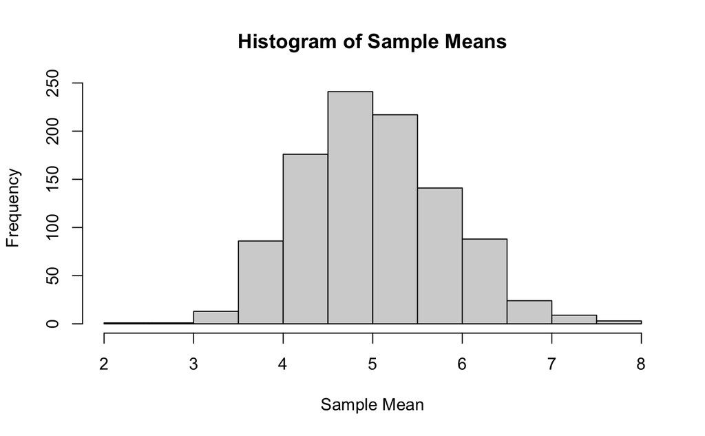

```r
hist(sample_means, main="Histogram of Sample Means", xlab="Sample Mean")
```

# Порівняння дисперсія середніх значень вибірок з теоретичною дисперсією розподілу

## Теоретична дисперсія

Теоретична дисперсія для середнього значення 40 експоненціальних розподілів дорівнює (1/λ)^2 / 40.

```r
theoretical_variance <- (1 / lambda)^2 / 40
theoretical_variance
```

```
[1] 0.625
```

## Дисперсія середніх значень

Дисперсія середніх значень вибірок обчислюється як:

```r
sample_variance <- var(sample_means)
sample_variance
```

```
[1] 0.6514869
```

# Розподіл середніх вибірок

Ми перевіряємо, чи розподіл середніх значень вибірок приблизно нормальний.

## Графік щільності

На гістограму накладено графік щільності.

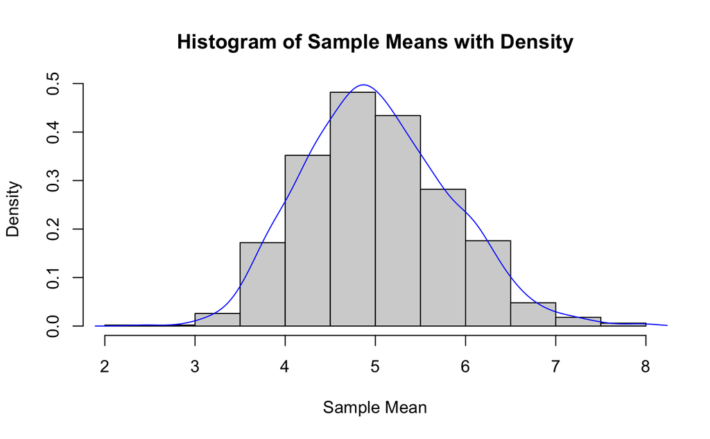

```r
hist(sample_means, main="Histogram of Sample Means with Density", xlab="Sample Mean", freq=FALSE)
lines(density(sample_means), col="blue")
```

## Q-Q Графік

Графік (Q-Q) використовується для візуальної оцінки нормальності.

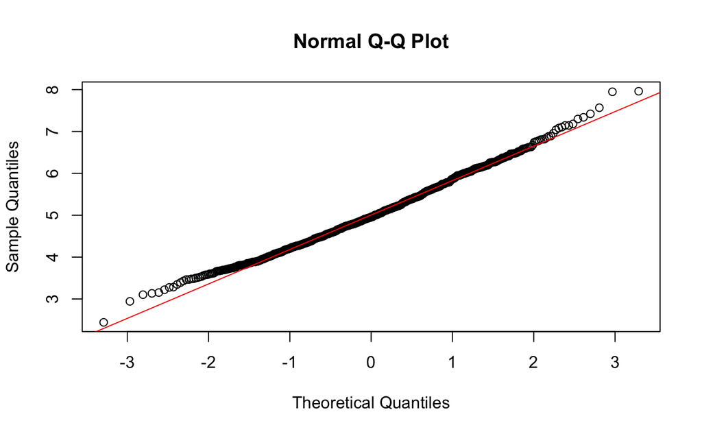

```r
qqnorm(sample_means)
qqline(sample_means, col="red")
```

## Висновки

Гістограма та графік Q-Q підказують, що розподіл середніх значень вибірок приблизно нормальний, відповідно до Центральної Граничної Теореми. Це демонструє, що навіть для ненормальних розподілів, таких як експоненціальний розподіл, середнє значення великої кількості вибірок буде схильне до нормального розподілу.